# Boxplots

## Preliminaries

### Load packagtes

```r
library(compbio4all)
library(ggplot2)
library(cowplot)
library(ggpubr)
```

### Load data

```r
data(frogarms)
```

## Boxplots

Basic boxplot

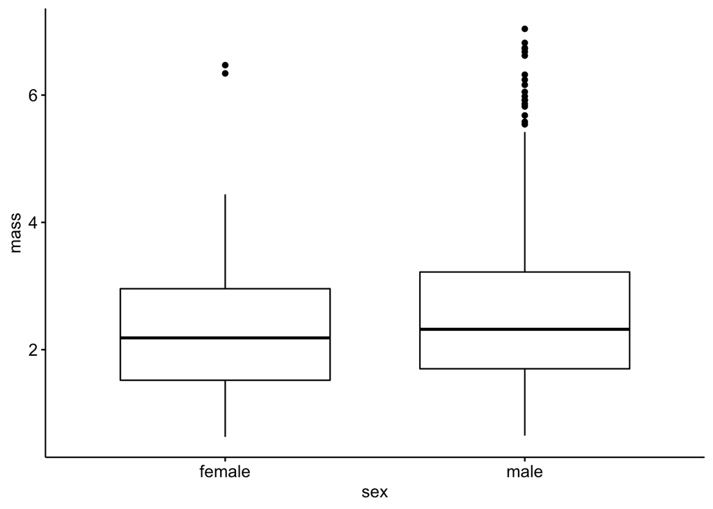

```r
ggboxplot(data = frogarms,
          y = "mass",
          x = "sex")
```

## Aside: Notched boxplots

We’ll use the original frogarms dataframe first for this THese aren’t commonly used; the notches work kind of like confidence intervals to determine if medians are different.

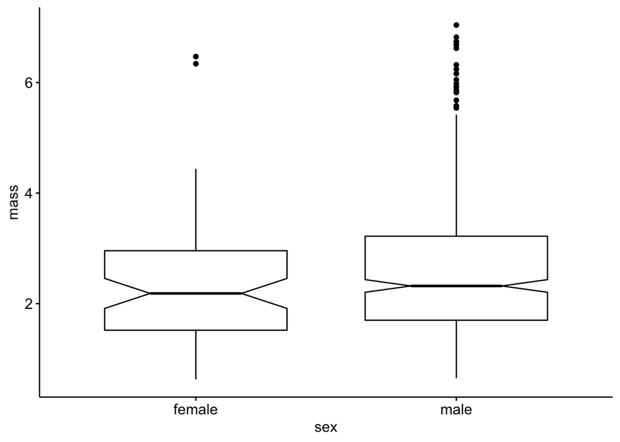

```r
ggboxplot(data = frogarms,
          y = "mass",
          x = "sex",
          notch  = TRUE)
```

## Fill

Add colored fill; note that it is “fill” not “color”. Color changes the color of the lines

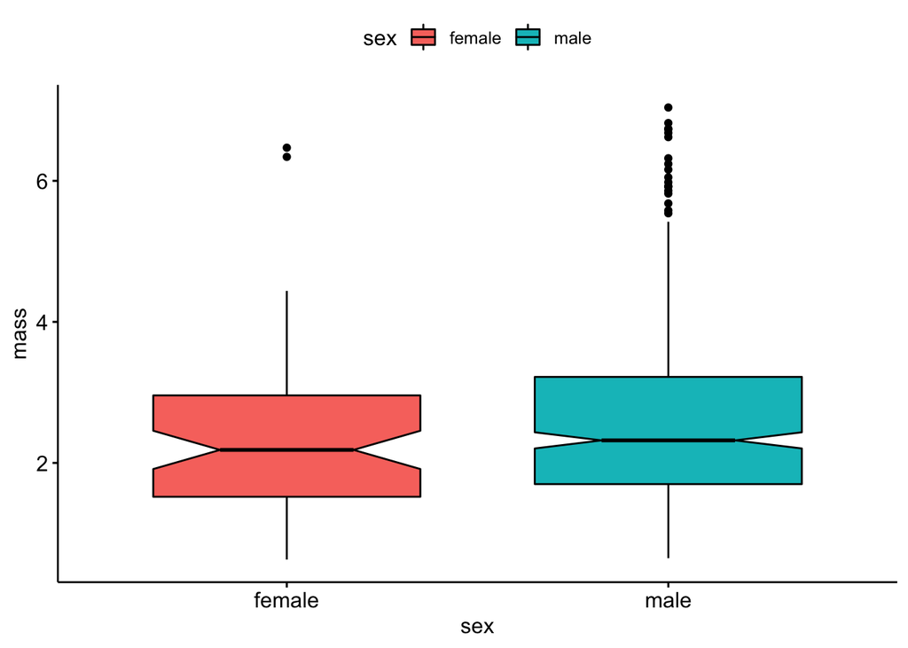

```r
ggboxplot(data = frogarms,
          y = "mass",
          x = "sex",
          notch  = TRUE,
          fill = "sex")
```

We can turn off the nothing by adding a “#” character before it. This is called “**commenting out**”

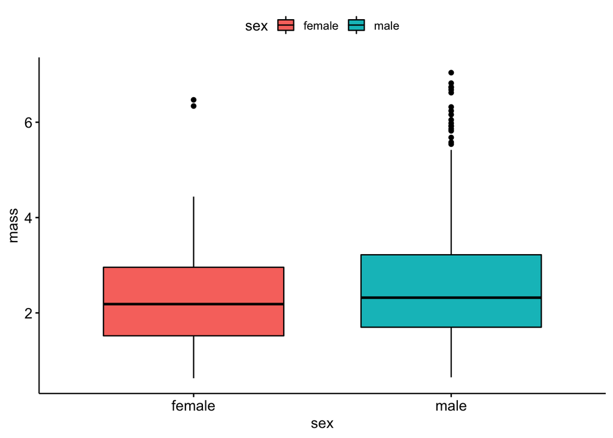

```r
ggboxplot(data = frogarms,
          y = "mass",
          x = "sex",
          #notch  = TRUE,
          fill = "sex")
```

## Adding raw data

Add raw data to the plot. This works best with small datasts

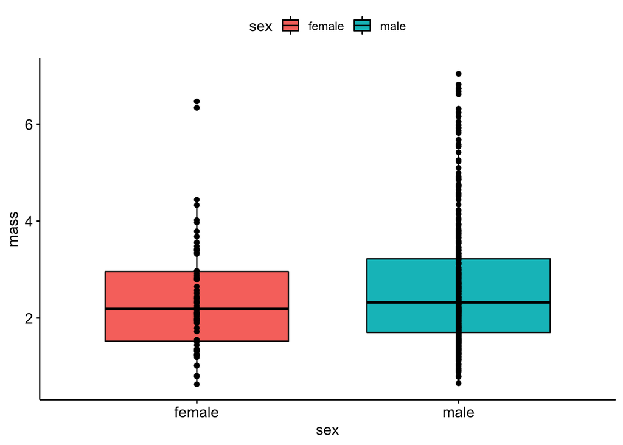

```r
ggboxplot(data = frogarms,
          y = "mass",
          x = "sex",
          #notch  = TRUE,
          fill = "sex",
          add = "point")
```

## Jitter the raw data

This can be helpful, though ggpubr::ggboxplot doesn’t allow much control over the “jittering”. Jittering helpful when you have large datsets and want to avoid overlap in the points.

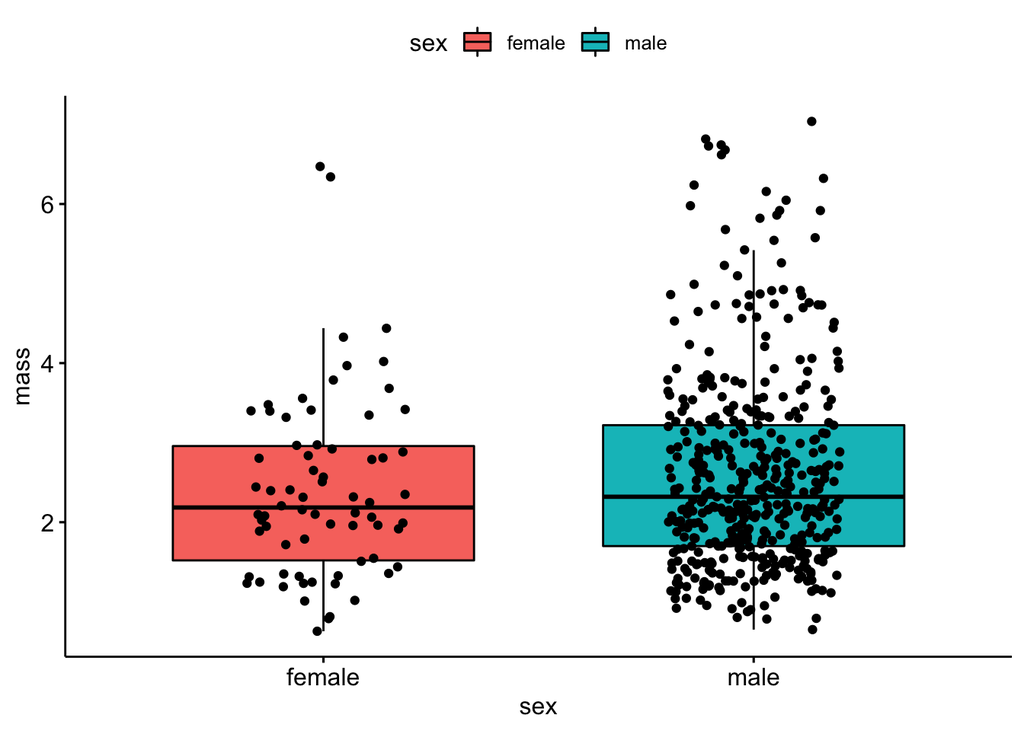

```r
ggboxplot(data = frogarms,
          y = "mass",
          x = "sex",
          #notch  = TRUE,
          fill = "sex",
          add = "jitter")
```

Label axes

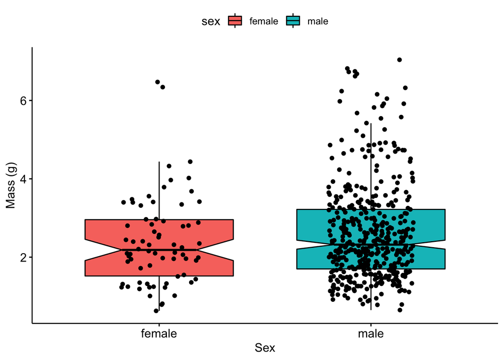

```r
ggboxplot(data = frogarms,
          y = "mass",
          x = "sex",
          notch  = TRUE,
          fill = "sex",
          add = "jitter",
          xlab = "Sex",      #x axis (horizontal)
          ylab = "Mass (g)") #y axis (vertical)
```

Add title not usually done for publication but useful for keeping track of things and for presentations

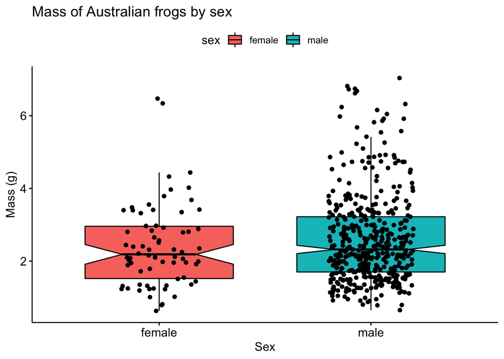

```r
ggboxplot(data = frogarms,
          y = "mass",
          x = "sex",
          notch  = TRUE,
          fill = "sex",
          add = "jitter",
          xlab = "Sex",
          ylab = "Mass (g)",
          main = "Mass of Australian frogs by sex") #Main title
```

Move legend to bottom

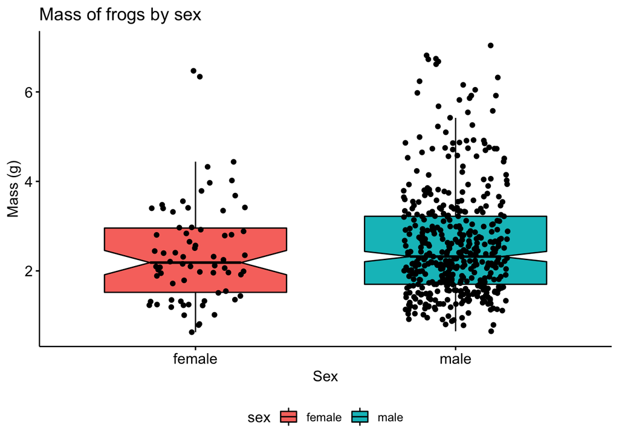

```r
ggboxplot(data = frogarms,
          y = "mass",
          x = "sex",
          notch  = TRUE,
          fill = "sex",
          add = "jitter",
          xlab = "Sex",
          ylab = "Mass (g)",
          main = "Mass of frogs by sex",
          legend = "bottom")
```

Change color pallete

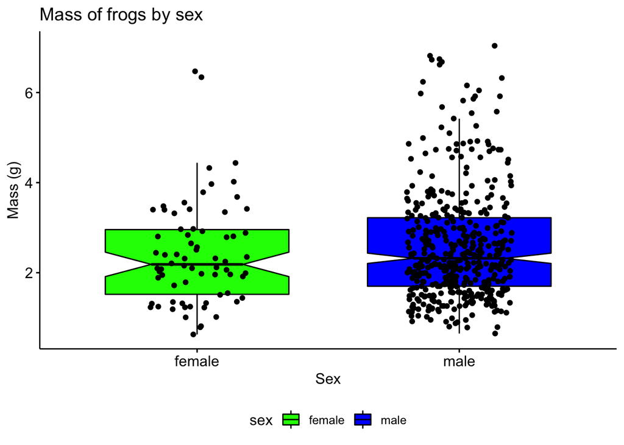

```r
ggboxplot(data = frogarms,
          y = "mass",
          x = "sex",
          notch  = TRUE,
          fill = "sex",
          add = "jitter",
          xlab = "Sex",
          ylab = "Mass (g)",
          main = "Mass of frogs by sex",
          legend = "bottom",
          palette = c("green","blue"))
```

### Plotting multple plots with cowplot::plot_grid

```r
my.frogs <- make_my_data2L(dat = frogarms,
                           my.code = "nlb24",  # <=  change this!
                           cat.var = "sex",
                           n.sample = 20,
                           with.rep = FALSE)
```

```
## Codes should only contain letters and numbers
## Your special code is  4782969
## (You don't really need to know this, though). 4782969
## NOTE: This function only works properly for data with TWO levels to the categorical var.
##  eg male vs. female; it doesn't work for >2 levels (eg red vs blue vs. green)
```

```r
dim(my.frogs)
```

```
## [1] 40  8
```

We can save a plot to an R object

```r
gg.my.frogs<- ggboxplot(data = my.frogs,
          y = "mass",
          x = "sex")
```

Call just the object (eg, just type it into the console. or highlight jsut the word)

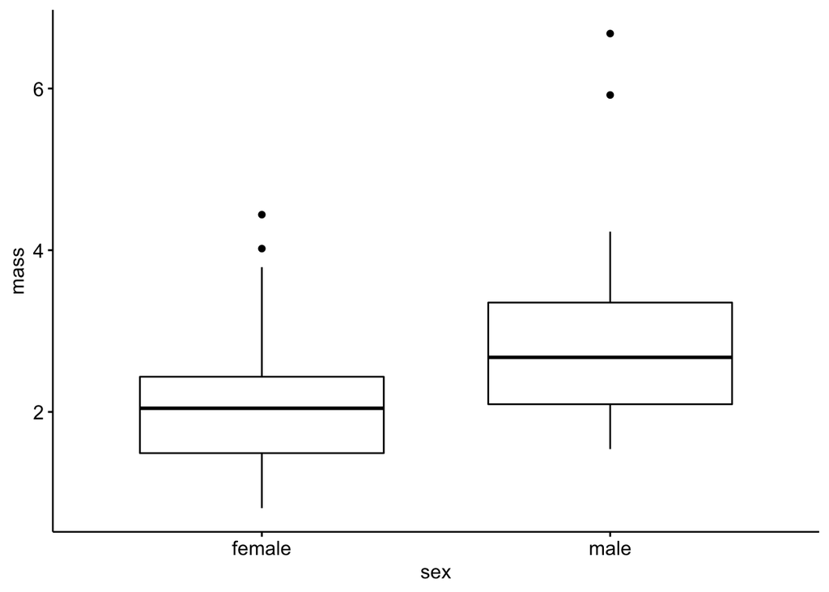

```r
gg.my.frogs
```

Make an object using the frogarms data

```r
gg.frogarms <- ggboxplot(data = frogarms, #use original data
          y = "mass",
          x = "sex")
```

Now plot both

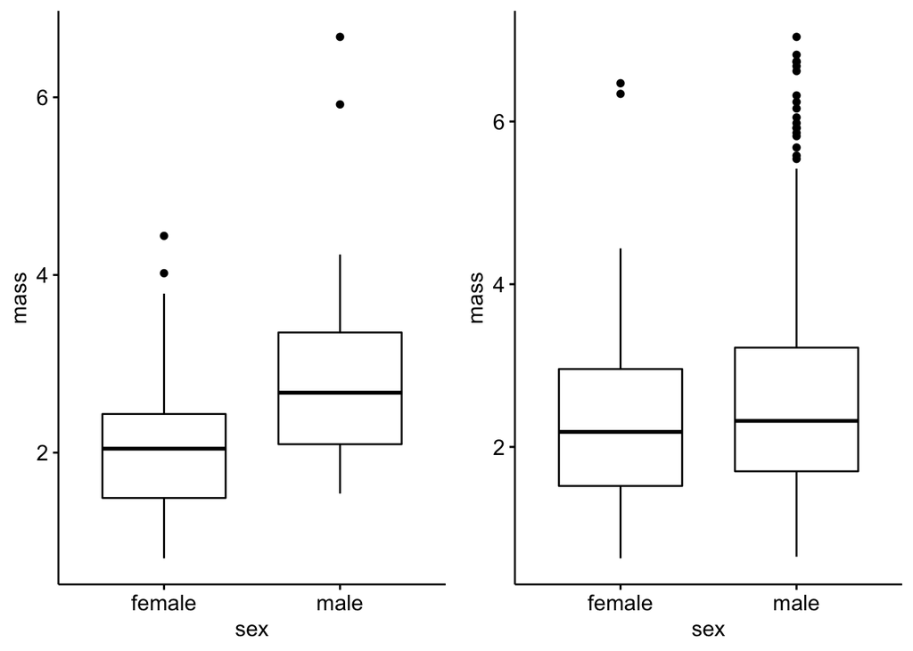

```r
plot_grid(gg.my.frogs,
          gg.frogarms)
```

Add labels. Note that alignment is off sometimes.

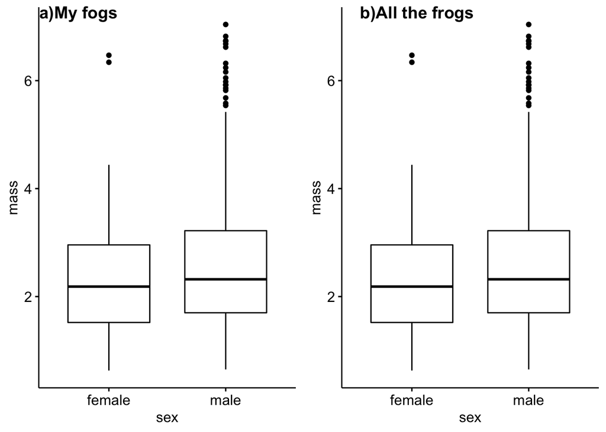

```r
plot_grid(gg.frogarms,
          gg.frogarms,
          labels = c("a)My fogs","b)All the frogs"))
```